# Estimating complex functions

PCB 6455 / BSC 4933: Biometry | Lecture 16

Dr. Brian Maitner

## Today’s agenda

- Tuesday: up to three parameters at once, each one a single number
- Today: a parameter that **changes from one observation to the next**
- The trick that keeps the optimizer alive
- Two case studies on Florida bobwhite: **where** they are and **how many**

Type and run on a code block: type it into your script and run it. You will need it later. Code without the label is there to watch.

## Where we are

| Section | Question | When |
| --- | --- | --- |
| 6.1 - 6.2 | What parameter values make my data most likely? | Tuesday |
| **6.3** | **What if the parameter depends on a covariate?** | **Today** |
| 6.4 - 6.5 | How sure am I about that parameter? | Next Tuesday |
| 6.6 | Which of two models is better? | Next Thursday |

Today is the last **mechanical** piece. After this, everything is about how much to trust the answer.

## You already did this

Tuesday’s last exercise, the one that estimated the decline:

```r
trend_nll <- function(mu0, decline, size){
  mu <- mu0 * (1 - decline)^year        # <- this line
  -sum(dnbinom(counts, mu = mu, size = size, log = TRUE))
}
```

**`mu` is not a number there. It is 1,360 numbers**, one per route-year, each computed from a covariate.

That is the whole of 6.3.

## The recipe

The **deterministic function** says what the parameter should be.

The **distribution** says how far the data can fall from it.

## Chapter 3 inside Chapter 4

| Piece | Chapter | Today’s first example |
| --- | --- | --- |
| Deterministic function | 3 | $p$ falls smoothly with year |
| Distribution | 4 | routes occupied $\sim$ Binomial($n$, $p$) |
| Parameters | 6 | the numbers in the curve: $a$ and $b$ |

In code it is always these three lines:

```r
nll <- function(parameters){
  predicted <- some_curve(covariate, parameters)      # chapter 3
  -sum(ddist(data, predicted, log = TRUE))            # chapter 4
}
```

## Today’s question

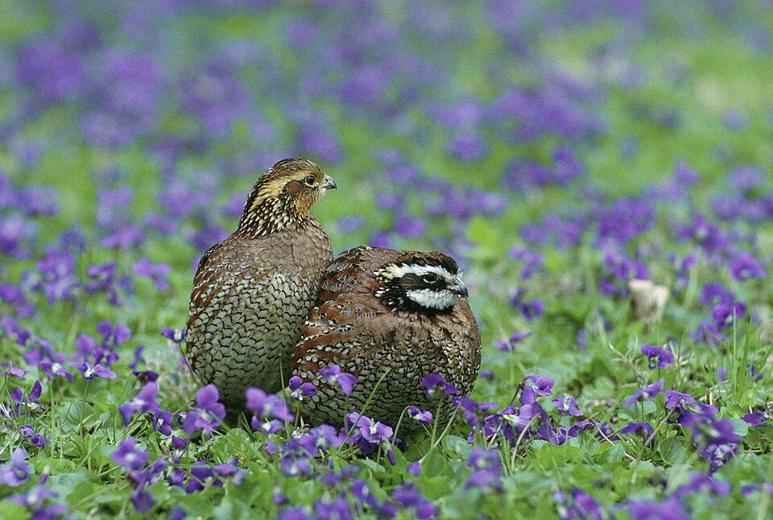

*Colinus virginianus*  
Photo: USFWS, public domain

Tuesday left us two numbers for this bird:

- counts fall about **2.9% a year**, from the trend model you fitted
- **52 of the 71 routes** surveyed in 2019 held bobwhite, so $\hat{p} = 0.73$

. . .

The first used all 23 years. The second used one.

. . .

**Is the share of routes holding bobwhite falling too, and how fast?**

## Get set up

```r
bbs <- read.csv("https://github.com/bmaitner/biometry_course/raw/refs/heads/main/data/BBS/FL_BBS.csv")

# how many routes were surveyed each year
n_routes_by_year <- tapply(bbs$Route, bbs$Year, function(x){ length(unique(x)) })

# how many of them had bobwhite
bob_all <- bbs[bbs$Scientific_Name == "Colinus virginianus", ]
n_occ_by_year <- tapply(bob_all$Route, bob_all$Year, function(x){ length(unique(x)) })

occ <- data.frame(year = as.numeric(names(n_routes_by_year)),
                  n_routes = as.vector(n_routes_by_year),
                  n_occupied = as.vector(n_occ_by_year))

occ <- occ[occ$n_routes > 10, ]           # 1996 had a single route: drop it
occ$elapsed <- occ$year - min(occ$year)   # 0, 1, 2, ... 22

head(occ)
```

## What 23 years look like

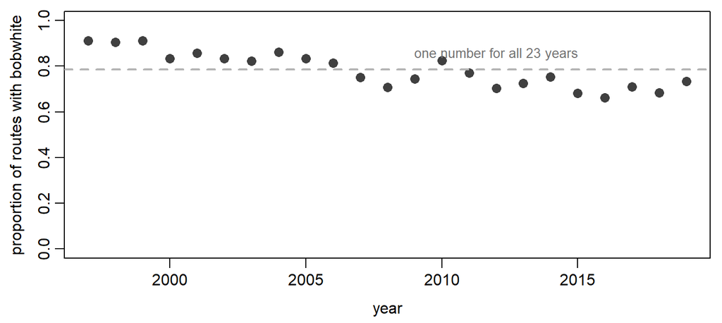

About **0.91** in 1997, about **0.73** in 2019. The dashed line ignores year entirely: a single $p$, for every route in every year.

## The one-number answer, and what it costs

```r
const_nll <- function(p){
  -sum(dbinom(occ$n_occupied, size = occ$n_routes, prob = p, log = TRUE))
}

const_fit <- optimize(const_nll, interval = c(0, 1))

c(p = const_fit$minimum, nll = const_fit$objective)
```

You get $p =$ 0.7855, which is just 1,359 occupied out of 1,730 surveyed. **Correct, and useless**: it cannot answer the question we asked.

Keep the other number it prints, the negative log-likelihood **79.9**. Every model we fit today has to beat it, and **lower is better**.

## What shape should $p$ take?

$p_t$ is the probability a route holds bobwhite in year $t$, counting from $t = 0$ in 1997. That is the `elapsed` column you just built.

**A straight line**

$$p_t = a + b t$$

$b$ is the change in probability per year, readable as it stands.

**A logistic curve**

$$p_t = \frac{1}{1 + e^{-(a + b t)}}$$

Flattens near 0 and 1, so it can never predict an impossible probability.

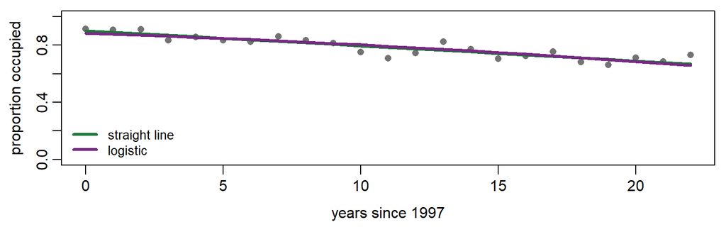

## Why the straight line breaks

```r
lin_nll <- function(a, b){
  p <- a + b * occ$elapsed
  -sum(dbinom(occ$n_occupied, size = occ$n_routes, prob = p, log = TRUE))
}

# a deliberately bad starting guess
optim(par = c(a = 0.5, b = 0.05),
      fn = function(p){
        lin_nll(p["a"], p["b"])
      },
      method = "BFGS")
```

```
Error in optim(...) : initial value in 'vmmin' is not finite
In addition: Warning message: NaNs produced
```

## Fixing it by transformation

Fit the line in a space with **no edges**, then squeeze the result into $(0, 1)$:

$$\log\left(\frac{p}{1-p}\right) = a + b t \qquad \Longleftrightarrow \qquad p = \frac{1}{1 + e^{-(a + b t)}}$$

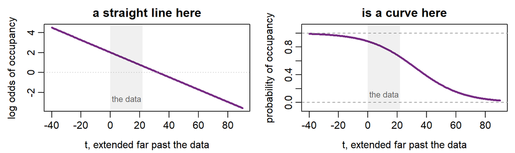

## Meet `plogis()`

```r
plogis(c(-3, -1, 0, 1, 3))   # log odds  ->  probability

qlogis(c(0.1, 0.5, 0.9))     # probability  ->  log odds

plogis(500)                  # however large the input, never above 1
```

| log_odds | probability |
| --- | --- |
| -3 | 0.047 |
| -1 | 0.269 |
| 0 | 0.500 |
| 1 | 0.731 |
| 3 | 0.953 |

## Writing the likelihood

Three steps, and only the first is new:

```r
occ_nll <- function(a, b){

  # 1. turn the two parameters into a probability for every year
  # 2. ask dbinom how likely the observed counts are, on the log scale
  # 3. add them up and flip the sign

}
```

Step 1 is `plogis(a + b * occ$elapsed)`.

Steps 2 and 3 are **exactly what you wrote on Tuesday**, unchanged.

## Your turn: fit the decline

```r
occ_nll <- function(a, b){
  p <- plogis(a + b * occ$elapsed)
  # your negative log-likelihood goes here
  # (dbinom wants x, size and prob: which column of occ is which?)
}

fit_occ <- optim(par = c(a = 2, b = -0.05),
                 fn = function(p){
                   # call your NLL here, with the two parameters
                 },
                 method = "BFGS")

fit_occ$par
fit_occ$value
```

**Is your `b` negative? And is `fit_occ$value` below 79.9**, the negative log-likelihood of the single-$p$ model?

## What the answer means

| parameter | estimate | meaning |
| --- | --- | --- |
| a | 2.0177 | log odds of occupancy in 1997 |
| b | -0.0619 | change in log odds per year |

- $a = 2.02$ is on the log odds scale, so occupancy in 1997 was `plogis(2.02)` = **0.88**
- $b = -0.062$ is **not** percentage points. `exp(-0.0619)` = 0.94, so the **odds fall about 6% per year**
- By 2019 the curve is down to **0.66**

**If you fit on a transformed scale, you have to transform back before you can say what the answer means.** The optimizer works in log odds. Nobody thinks in log odds. The same holds in the second half of today, with `exp()` in place of `plogis()`.

## Check it by plotting

```r
plot(occ$elapsed, occ$n_occupied / occ$n_routes, pch = 16,
     ylim = c(0, 1), xlab = "years since 1997", ylab = "proportion occupied")

elapsed_seq <- 0:22

lines(elapsed_seq,
      plogis(fit_occ$par["a"] + fit_occ$par["b"] * elapsed_seq),
      col = "red", lwd = 3)
```

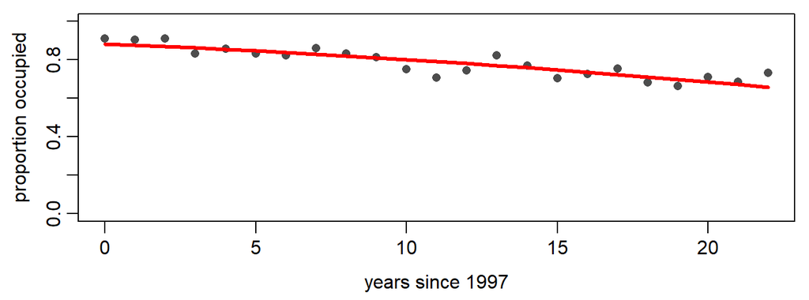

## Was the trend worth fitting?

| model | parameters | NLL |
| --- | --- | --- |
| one p for all years | 1 | 79.91 |
| p declines with year | 2 | 56.69 |

**23.2 log-likelihood units** for one extra parameter.

Is 23 units enough to justify a parameter? **That is next Thursday.** For now: clearly yes, and we will learn how to say so properly.

## What about that straight line?

Stop it from proposing illegal probabilities and it fits perfectly well. In fact it fits **slightly better**:

| shape | parameters | NLL |
| --- | --- | --- |
| straight line, guarded | 2 | 55.57 |
| logistic | 2 | 56.69 |

So why not use it?

- 1.12 units on 23 points is **nothing**, and next Thursday gives us the test to say so
- it only fits at all because we hand-wrote a guard around it
- run it to 2100 and it predicts an occupancy of **-0.19**

**Fit is one criterion. It is not the only one.**

## You just built a GLM by hand

```r
glm(cbind(n_occupied, n_routes - n_occupied) ~ elapsed,
    data = occ, family = binomial)$coefficients
```

```
(Intercept)     elapsed
  2.0177555  -0.0619034
```

The same two numbers, to three decimals. A **binomial GLM** is exactly what you just wrote: a logistic curve inside a binomial likelihood.

So why write it by hand? Because `glm()` knows a short list of shapes, and **the next case study is not on the list.**

## Keeping parameters legal

| The parameter must be | Fit this instead | Get back with |
| --- | --- | --- |
| a probability in $(0,1)$ | the log odds | `plogis()` |
| positive: `sd`, `size`, a rate | its logarithm | `exp()` |
| unconstrained | itself | nothing |

This is why the book writes things like `sd = exp(params[3])`. It is not a statistical statement. It is a fence to keep the optimizer out of the region where the likelihood is undefined.

## Bounds, or a transformation?

Tuesday we used bounds instead: `method = "L-BFGS-B"`, with `lower` and `upper`.

|  | Use it when |
| --- | --- |
| **Bounds** | the parameter itself must stay in a range: `size > 0` |
| **Transformation** | a **computed** quantity must stay in range for every observation |

Today needed the transformation: bounds on $a$ and $b$ cannot guarantee that $a + bt$ lands inside $(0,1)$ for all 23 years.

## Passing the data in

So far the likelihood reached out and grabbed `occ` from the workspace. Fine in a lecture, a trap in a project:

```r
occ_nll <- function(a, b){
  p <- plogis(a + b * occ$elapsed)        # where did occ come from?
  ...
}
```

Change `occ` and the function silently means something different. Better, and the form `mle2()` expects:

```r
occ_nll2 <- function(params, n_occupied, n_routes, elapsed){
  p <- plogis(params[1] + params[2] * elapsed)
  -sum(dbinom(n_occupied, size = n_routes, prob = p, log = TRUE))
}
```

## The same fit with `mle2()`

```r
library(bbmle)

occ_nll2 <- function(params, n_occupied, n_routes, elapsed){
  p <- plogis(params[1] + params[2] * elapsed)
  -sum(dbinom(n_occupied, size = n_routes, prob = p, log = TRUE))
}

parnames(occ_nll2) <- c("a", "b")        # mle2 insists on names

m_occ <- mle2(minuslogl = occ_nll2,
              start = c(a = 2, b = -0.05),
              data = list(n_occupied = occ$n_occupied,
                          n_routes = occ$n_routes,
                          elapsed = occ$elapsed))

coef(m_occ)
```

## The book’s version of today

Bolker’s 6.3 does the same thing with tadpoles and predators:

$$p = \frac{a}{1 + a h N}$$

- $N$ is the number of tadpoles stocked, the covariate
- $a$ is attack rate, $h$ is handling time, the parameters
- the number eaten is **binomial** with that $p$

Same three lines. A different curve from the Chapter 3 bestiary.

```r
library(emdbook)
data(ReedfrogFuncresp)       # if you want to follow the book exactly
```

## Occupancy, or abundance?

We asked **whether** bobwhite are there.

The counts say **how many**.

## Where are bobwhite still doing well?

Each BBS route carries landscape data, including `frac_built`: the fraction of the route’s surroundings that is developed.

Bobwhite need **early-succession** habitat: old fields, field edges, pine savanna kept open by fire.

**Does the count fall as development rises, and by how much?**

## Get set up, again

```r
y_bob <- bob_all$total_sightings    # birds counted on a route in a year
u_bob <- bob_all$frac_built         # fraction developed around that route

length(y_bob)                       # 1360 route-years

plot(u_bob, y_bob, pch = 16, col = rgb(0, 0, 0, 0.25),
     xlab = "fraction developed", ylab = "bobwhite counted")
```

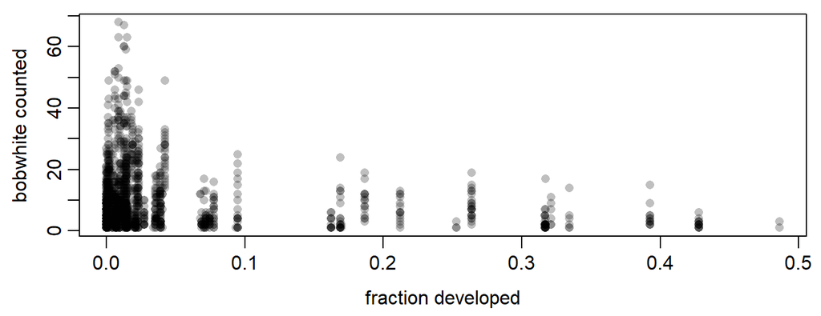

## Choosing the shape

$\mu$ is the expected count on a route and $u$ its fraction developed, the `u_bob` you just made. $\mu_0$ is the count where nothing is built.

| Candidate | Equation | The problem with it |
| --- | --- | --- |
| straight line | $\mu = \mu_0 + b u$ | goes negative, and $\mu$ must be positive |
| power law | $\mu = \mu_0 u^{\,b}$ | infinite at $u = 0$, and 78 routes have $u = 0$ |
| **exponential** | $\mu = \mu_0 e^{\,bu}$ | **positive everywhere, finite at zero** |

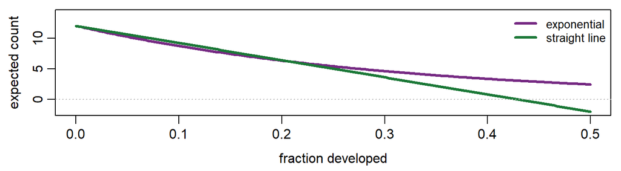

## Choosing the distribution

```r
mean(y_bob)
var(y_bob)
var(y_bob) / mean(y_bob)
```

| quantity | value | Poisson_expects |
| --- | --- | --- |
| mean | 10.78 |  |
| variance | 111.44 |  |
| variance / mean | 10.34 | 1 |

**10.3**, not 1. Counts, overdispersed, so **negative binomial**, exactly as on Tuesday.

## Your turn: fit the habitat effect

```r
urban_nll <- function(mu0, b, size){
  mu <- mu0 * exp(b * u_bob)
  # your negative log-likelihood goes here
  # (three parameters now, and mu is a vector)
}

fit_urban <- optim(par = c(mu0 = 12, b = -3, size = 1.4),
                   fn = function(p){
                     # call your NLL here, with the three parameters
                   },
                   method = "L-BFGS-B",
                   lower = c(0.1, -20, 0.05),
                   upper = c(100, 20, 50))

fit_urban$par
fit_urban$value
```

**What count does your model expect on an undeveloped route? On one that is 20% developed?**

## What it means

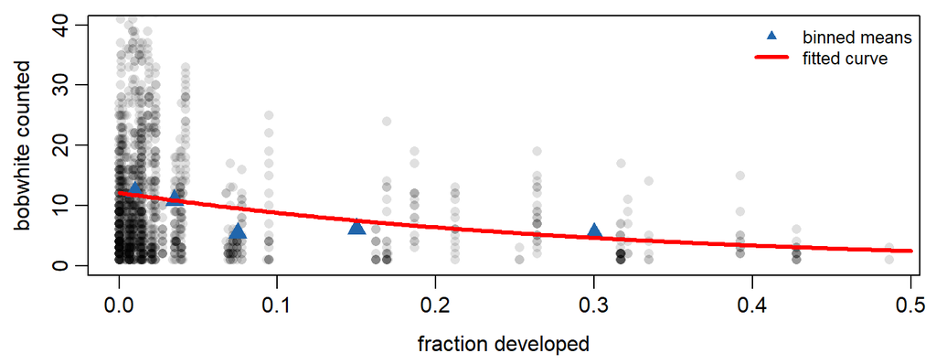

- $\mu_0 =$ **12.1** birds where nothing is built
- 6.4 birds at 20% developed, **2.4** at 50%
- Halved by **21%** development, since $\log(2) / |b|$ = 0.215

## Three models, one dataset

All three fit the same 1,360 counts with a negative binomial:

| model | parameters | NLL |
| --- | --- | --- |
| mu is constant | 2 | 4626.8 |
| mu declines with year (Tuesday) | 3 | 4595.6 |
| mu declines with development (today) | 3 | 4574.1 |

The last two cost the **same** number of parameters, so no test is needed to compare them: development fits better by **21** units.

## What this cannot tell you

**`frac_built` is measured once per route.** It does not change over the 23 years.

So it can explain **where** bobwhite are scarce. It cannot explain **why they declined**: a variable that does not change over time cannot account for a change over time.

And the counts file holds only routes where the species was **seen**, so the zeros are missing. Occupancy had the zeros; abundance has the counts. **You need both halves**, which is why we fit both.

## What you can now do

- Put a **Chapter 3 curve** inside a **Chapter 4 distribution**
- Transform a constrained parameter so the optimizer stays in legal territory
- Fit it, interpret it on the right scale, and plot it over the data
- Compare two shapes by their negative log-likelihood

Still missing: **how sure are you about $b$?** That is next Tuesday.

## Additional practice

Reef fish richness against depth. Same five steps, less handholding:

```r
reef <- read.csv("https://github.com/bmaitner/biometry_course/raw/refs/heads/main/data/Reef_fish/NCRMP_reef_fish_surveys.csv")
depth <- reef$DEPTH
rich <- reef$species_richness
# 1. look first. flat, rising, or humped?
plot(depth, rich, pch = 16, col = rgb(0, 0, 0, 0.05))
# 2. which distribution? run Tuesday's check before you decide
var(rich) / mean(rich)
# 3. a hump needs three numbers: how high, where, and how wide
reef_nll <- function(peak, opt, width, size){
  mu <- peak * exp(-(depth - opt)^2 / (2 * width^2))
  # your negative log-likelihood goes here
}
# 4. four parameters, so bounds are worth having
fit_reef <- optim(par = c(peak = 25, opt = 20, width = 15, size = 10),
                  fn = function(p){
                    # your NLL, with four parameters this time
                  },
                  method = "L-BFGS-B",
                  lower = c(1, 0, 1, 0.1), upper = c(200, 60, 200, 1000))
# 5. plot the curve over the cloud. does it match the hump from step 1?
```

## Before next class

Read Bolker **6.4** (6.4.2 optional), and skim **6.5**

Next time: **confidence intervals**, and what the shape of the likelihood surface tells you about how sure you are